# Binary Classification Models Using R: United States Airline Satisfaction Data

December 20, 2018

## Introduction

- U.S Airline Satisfaction Data
- From kaggle.com
- Target variable is customer satisfaction

## Variables

```
## 'data.frame':    129880 obs. of  23 variables:
##  $ target                           : Factor w/ 2 levels "neutral or dissatisfied",..: 2 2 2 2 2 2 2 2 2 2 ...
##  $ gender                           : Factor w/ 2 levels "Female","Male": 1 2 1 1 1 2 1 2 1 2 ...
##  $ customertype                     : Factor w/ 2 levels "disloyal Customer",..: 2 2 2 2 2 2 2 2 2 2 ...
##  $ age                              : int  65 47 15 60 70 30 66 10 56 22 ...
##  $ traveltype                       : Factor w/ 2 levels "Business travel",..: 2 2 2 2 2 2 2 2 2 2 ...
##  $ class                            : Factor w/ 3 levels "Business","Eco",..: 2 1 2 2 2 2 2 2 1 2 ...
##  $ flight.distance                  : int  265 2464 2138 623 354 1894 227 1812 73 1556 ...
##  $ seat.comfort                     : int  0 0 0 0 0 0 0 0 0 0 ...
##  $ departure.arrival.time.convenient: int  0 0 0 0 0 0 0 0 0 0 ...
##  $ food.and.drink                   : int  0 0 0 0 0 0 0 0 0 0 ...
##  $ gate.location                    : int  2 3 3 3 3 3 3 3 3 3 ...
##  $ inflight.wifi.service            : int  2 0 2 3 4 2 2 2 5 2 ...
##  $ inflight.entertainment           : int  4 2 0 4 3 0 5 0 3 0 ...
##  $ online.support                   : int  2 2 2 3 4 2 5 2 5 2 ...
##  $ ease.of.online.booking           : int  3 3 2 1 2 2 5 2 4 2 ...
##  $ on.board.service                 : int  3 4 3 1 2 5 5 3 4 2 ...
##  $ leg.room.service                 : int  0 4 3 0 0 4 0 3 0 4 ...
##  $ baggage.handling                 : int  3 4 4 1 2 5 5 4 1 5 ...
##  $ checkin.service                  : int  5 2 4 4 4 5 5 5 5 3 ...
##  $ cleanliness                      : int  3 3 4 1 2 4 5 4 4 4 ...
##  $ online.boarding                  : int  2 2 2 3 5 2 3 2 4 2 ...
##  $ departdelay                      : int  0 310 0 0 0 0 17 0 0 30 ...
##  $ arrivaldelay                     : int  0 305 0 0 0 0 15 0 0 26 ...
```

- Number of missing values:

```
## [1] 393
```

## Target Variable Distribution

This chart gives us an idea of about how often a customer is left satisfied showing that the data in the target variable is well balanced.

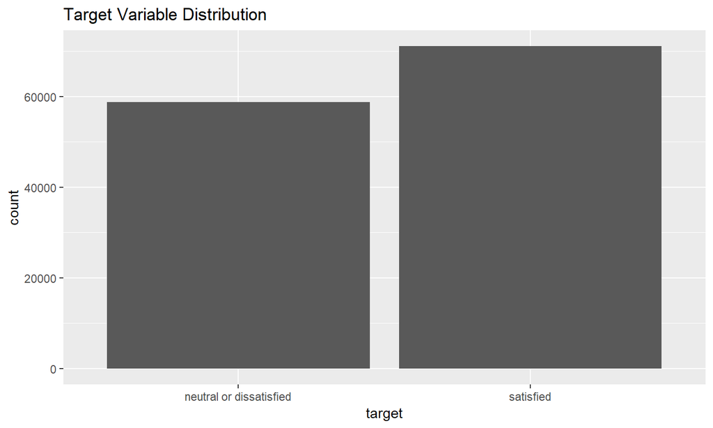

## Inflight Entertainment by Satisfaction

Inflight Entertainment played a large role in customer satisfaction.

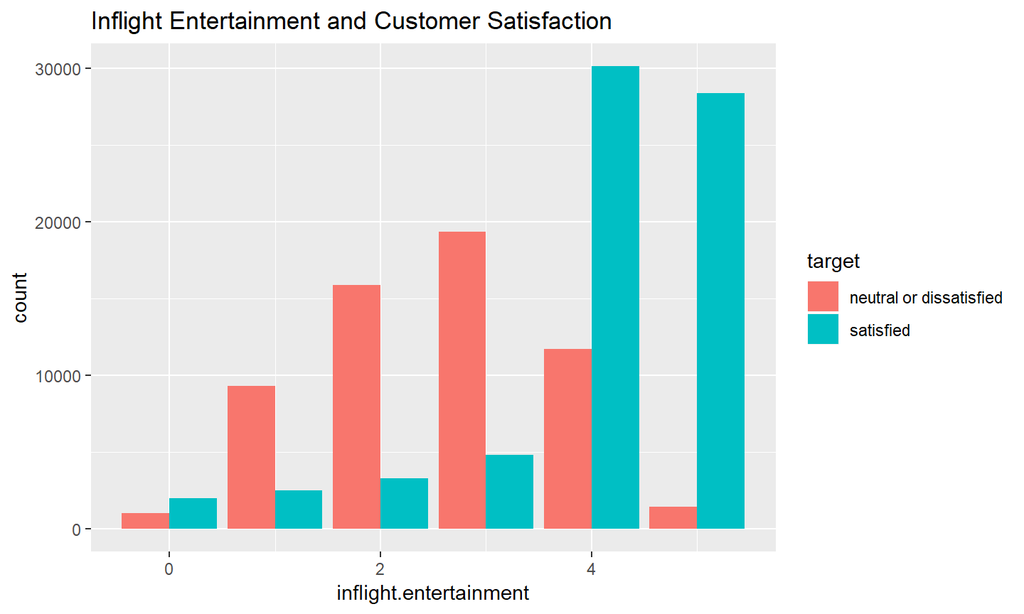

## Seat Comfort by Satisfaction

Seat Comfort also played a large role in whether or not the customer was satisfied.

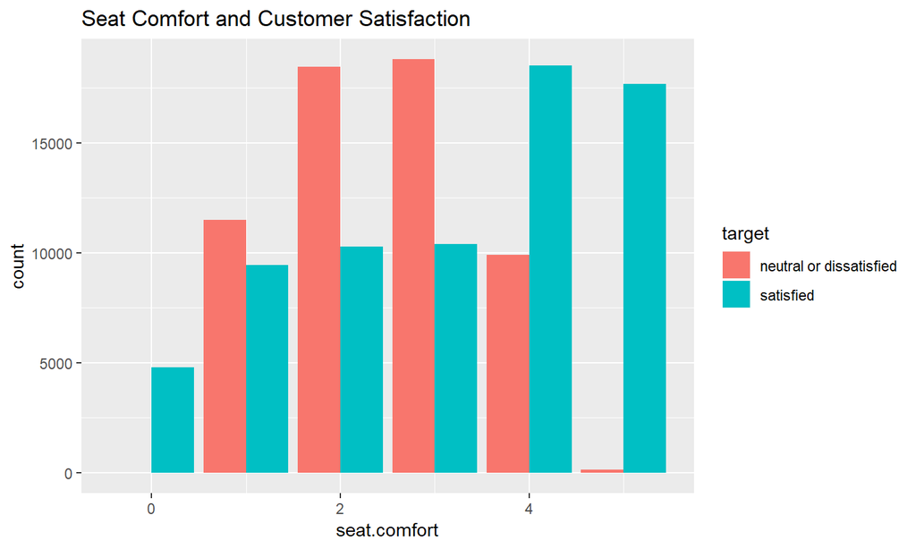

## Customer Satisfaction by Age

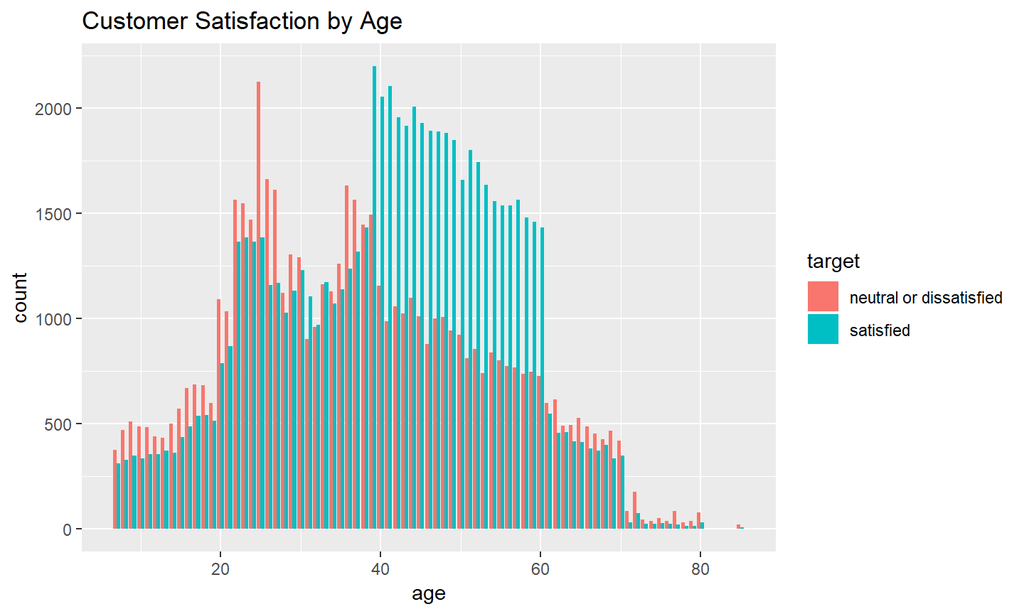

## Variable Correlation Exploration

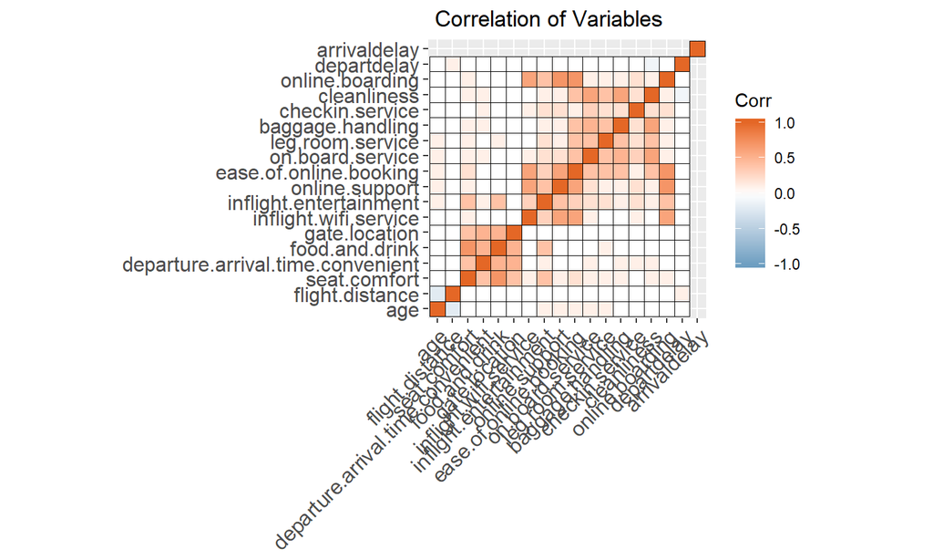

## Does Flight Distance Affect Satisfaction?

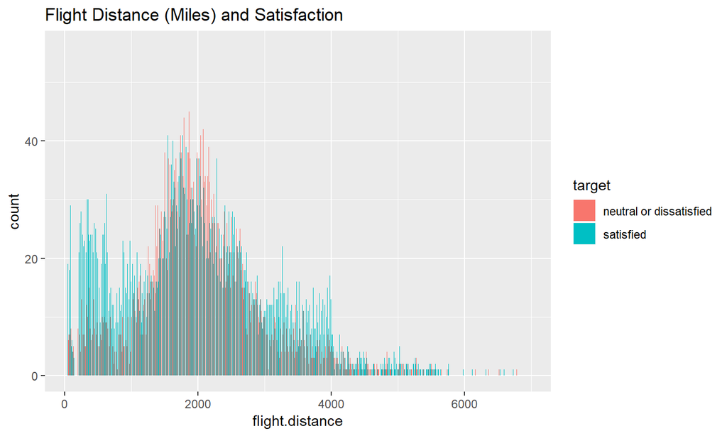

## Is satisfaction influenced by customer type?

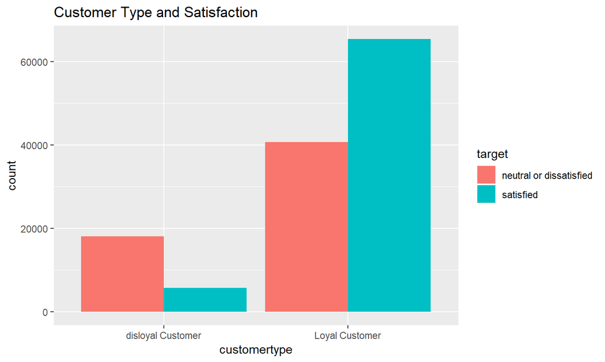

## Handling missing values

- The first way used to handle missing values was to use the median impute method: medianImpute.
- The second way used to handle missing values was to use the knn method: knnImpute.
- The third way used to handle missing values was to use the bagging method: bagImpute.

## Decision Trees Performance on Imputation Methods

- Median Impute proved to have the best accuracy. Used median imputed data going forward.
- Encoding the categorical variables improved accuracy and cp of the decision tree.
- Accuracy was .827 CP was .01355
- Encoded data produced accuracy of .829 and CP of .0087

## Model Results

- Decision Tree Tuned: Accuracy of .86 and CP held constant at .005
- Random Forest: The final values used for the model were mtry = 19, splitrule = gini and min.node.size = 1. Accuracy of .9196 (Champion Model)
- GLM: The final values used for the model were alpha = 0.1 and lambda = 0.000597716. Accuracy of .862
- Neural Network: The final values used for the model were size = 5 and decay = 0.1. Accuracy of .852
- Neural Network Tuned: Tuning parameter 'size' was held constant at a value of 3 Tuning parameter 'decay' was held constant at a value of 0.2. Accuracy of .852